# GO Enrichment Analysis of CESA Knockout DEGs

Kerrina Whelan

2025-04-30

## Introduction

This report summarizes Gene Ontology (GO) enrichment analysis results for biological processes (BP), molecular functions (MF), and cellular components (CC) using PANTHER data. The analysis includes barplots and pie charts to visualize significant GO terms. The GO enrichment was performed on differentially expressed genes (DEGs) identified from RNA-seq data in a CESA knockout mutant of *Physcomitrium patens*.

### GO Bar Plot (Top 15 Biological Processes)

A bar plot of the top 15 enriched biological processes was created based on fold enrichment values. This exploratory figure provided an initial functional classification of CESA knockout DEGs to guide deeper statistical analysis of biological processes.

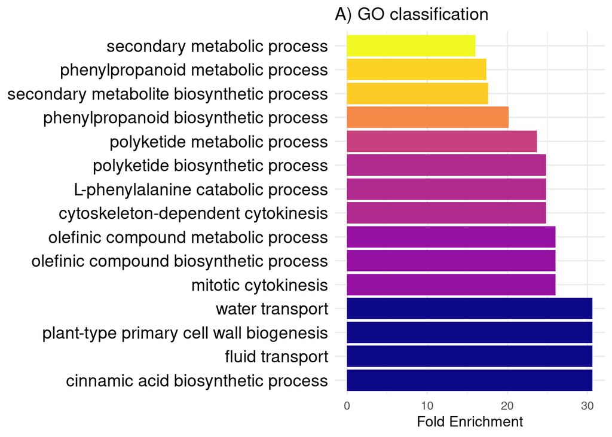

**Figure 1.** Secondary metabolism, transport, and cell wall biogenesis processes are enriched in CESA knockout DEGs. GO enrichment analysis was performed on DEGs from *P. patens* CESA knockout lines (n = 3 biological replicates) using the PANTHER classification system. Fold enrichment and FDR-adjusted p-values were calculated for biological process (BP) terms. Only terms with FDR < 0.05 were retained, and the top 15 enriched BP terms were plotted. Bars represent fold enrichment for each GO term, with color intensity indicating enrichment magnitude. Enriched biological processes include secondary metabolism, cytoskeleton-dependent cytokinesis, water transport, and cell wall biogenesis, suggesting that CESA disruption activates metabolic, transport, and structural remodeling pathways.